# Sleep Dataset

Adapted from: http://www.ucd.ie/ecomodel/Resources/Sheet3_visualisation_WebVersion.html Dr Jon Yearsley (School of Biology and Environmental Science, UCD)

```r
if (!require("UsingR")) install.packages("UsingR"); library(UsingR)
if (!require("cowplot")) install.packages("cowplot"); library(cowplot)
if (!require("tidyverse")) install.packages("tidyverse"); library(tidyverse)
```

This is an updated and expanded version of the mammals sleep dataset. Updated sleep times and weights were taken from V. M. Savage and G. B. West. A quantitative, theoretical framework for understanding mammalian sleep. Proceedings of the National Academy of Sciences, 104 (3):1051-1056, 2007. http://www.pnas.org/content/104/3/1051.abstract

`r`r data(msleep) summary(msleep)

```
     name              genus               vore
 Length:83          Length:83          Length:83
 Class :character   Class :character   Class :character
 Mode  :character   Mode  :character   Mode  :character




    order           conservation        sleep_total      sleep_rem
 Length:83          Length:83          Min.   : 1.90   Min.   :0.100
 Class :character   Class :character   1st Qu.: 7.85   1st Qu.:0.900
 Mode  :character   Mode  :character   Median :10.10   Median :1.500
                                       Mean   :10.43   Mean   :1.875
                                       3rd Qu.:13.75   3rd Qu.:2.400
                                       Max.   :19.90   Max.   :6.600
                                                       NA's   :22
  sleep_cycle         awake          brainwt            bodywt
 Min.   :0.1167   Min.   : 4.10   Min.   :0.00014   Min.   :   0.005
 1st Qu.:0.1833   1st Qu.:10.25   1st Qu.:0.00290   1st Qu.:   0.174
 Median :0.3333   Median :13.90   Median :0.01240   Median :   1.670
 Mean   :0.4396   Mean   :13.57   Mean   :0.28158   Mean   : 166.136
 3rd Qu.:0.5792   3rd Qu.:16.15   3rd Qu.:0.12550   3rd Qu.:  41.750
 Max.   :1.5000   Max.   :22.10   Max.   :5.71200   Max.   :6654.000
 NA's   :51                       NA's   :27
```

The msleep dataset has 11 variables: name = species common name genus = genus name vore = feeding type (carnivore/herbivore/omnivore/insectivore) order = name of the order conservation = the IUCN conservation status of the species (lc/nt/en/domesticated vu/cd) sleep_total = total sleep time (hours) sleep_rem = REM sleep time (hours) sleep_cycle = length of sleep cycle (hours) awake = time spent awake (hours) brainwt = brain weight (kg) bodywt = body weight (kg)

`r`r msleep

| name | genus | vore | order | conservation | sleep_total | sleep_rem | sleep_cycle | awake | brainwt | bodywt |
| --- | --- | --- | --- | --- | --- | --- | --- | --- | --- | --- |
| Cheetah | Acinonyx | carni | Carnivora | lc | 12.1 | NA | NA | 11.90 | NA | 50.000 |
| Owl monkey | Aotus | omni | Primates | NA | 17.0 | 1.8 | NA | 7.00 | 0.01550 | 0.480 |
| Mountain beaver | Aplodontia | herbi | Rodentia | nt | 14.4 | 2.4 | NA | 9.60 | NA | 1.350 |
| Greater short-tailed shrew | Blarina | omni | Soricomorpha | lc | 14.9 | 2.3 | 0.1333333 | 9.10 | 0.00029 | 0.019 |
| Cow | Bos | herbi | Artiodactyla | domesticated | 4.0 | 0.7 | 0.6666667 | 20.00 | 0.42300 | 600.000 |
| Three-toed sloth | Bradypus | herbi | Pilosa | NA | 14.4 | 2.2 | 0.7666667 | 9.60 | NA | 3.850 |
| Northern fur seal | Callorhinus | carni | Carnivora | vu | 8.7 | 1.4 | 0.3833333 | 15.30 | NA | 20.490 |
| Vesper mouse | Calomys | NA | Rodentia | NA | 7.0 | NA | NA | 17.00 | NA | 0.045 |
| Dog | Canis | carni | Carnivora | domesticated | 10.1 | 2.9 | 0.3333333 | 13.90 | 0.07000 | 14.000 |
| Roe deer | Capreolus | herbi | Artiodactyla | lc | 3.0 | NA | NA | 21.00 | 0.09820 | 14.800 |

[output cut: 73 more lines]

Begin exploring the data by looking at how many species are included for each feeding type

`r`r table(msleep$vore)

```
  carni   herbi insecti    omni
     19      32       5      20
```

This could also be viewed in a barplot. Note that this shows more information because it includes “NA” values.

`r`r ggplot(msleep) + aes(x = vore) + geom_bar() + theme_cowplot()

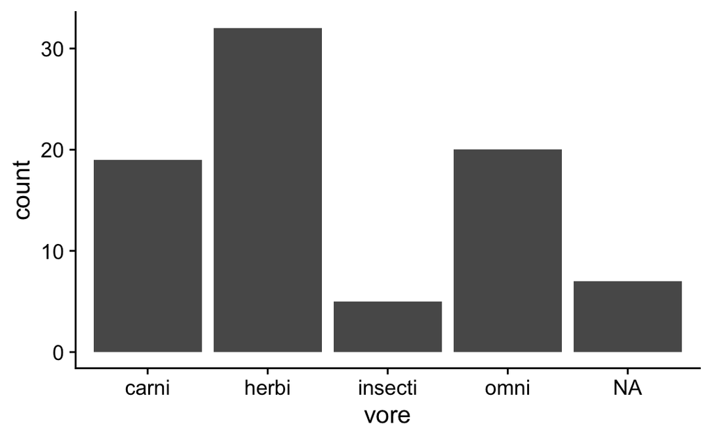

We could also look at this in a pie chart. (By why would we?)

We can look at two different categorical variables at once in a contingency table

`r`r table(msleep$order, msleep$vore)

```
                  carni herbi insecti omni
  Afrosoricida        0     0       0    1
  Artiodactyla        0     5       0    1
  Carnivora          12     0       0    0
  Cetacea             3     0       0    0
  Chiroptera          0     0       2    0
  Cingulata           1     0       1    0
  Didelphimorphia     1     0       0    1
  Diprotodontia       0     1       0    0
  Erinaceomorpha      0     0       0    1
  Hyracoidea          0     2       0    0
  Lagomorpha          0     1       0    0
  Monotremata         0     0       1    0
  Perissodactyla      0     3       0    0
  Pilosa              0     1       0    0
  Primates            1     1       0   10
  Proboscidea         0     2       0    0
  Rodentia            1    16       0    2
  Scandentia          0     0       0    1
  Soricomorpha        0     0       1    3
```

Now lets look at some of the quantitative variables. A histogram can summarize the distribution of the variables.

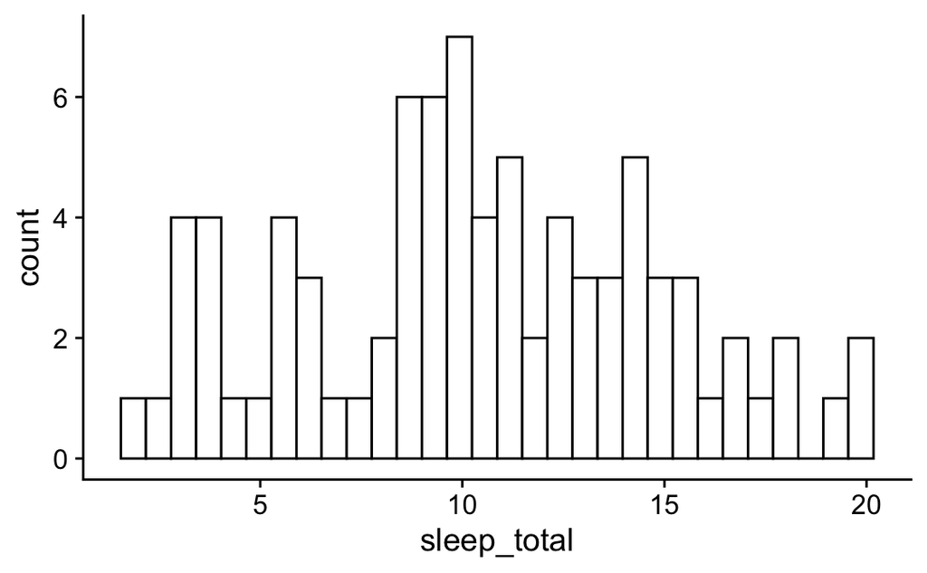

Mmmmmm. 20 hours of sleep!

An important factor to consider when exploring data is whether it is normally distributed (or matches some other expected distribution). This is most easily visualized using a quantile-quantile (Q-Q plot) to determine the difference between each data point and the normal distribution (the residuals).

`r`r qqnorm(msleep$sleep_total, main='Normal Q-Q Plot for sleep_total') qqline(msleep$sleep_total)

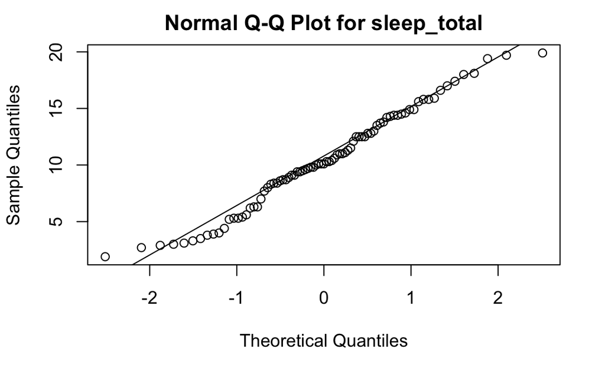

The normal distribution (qnorm) isn’t bad for this data. To see an example where the fit is not good, take a look at the distribution of residuals in REM sleep.

`r`r qqnorm(msleep$sleep_rem, main='Normal Q-Q Plot for sleep_rem') qqline(msleep$sleep_rem)

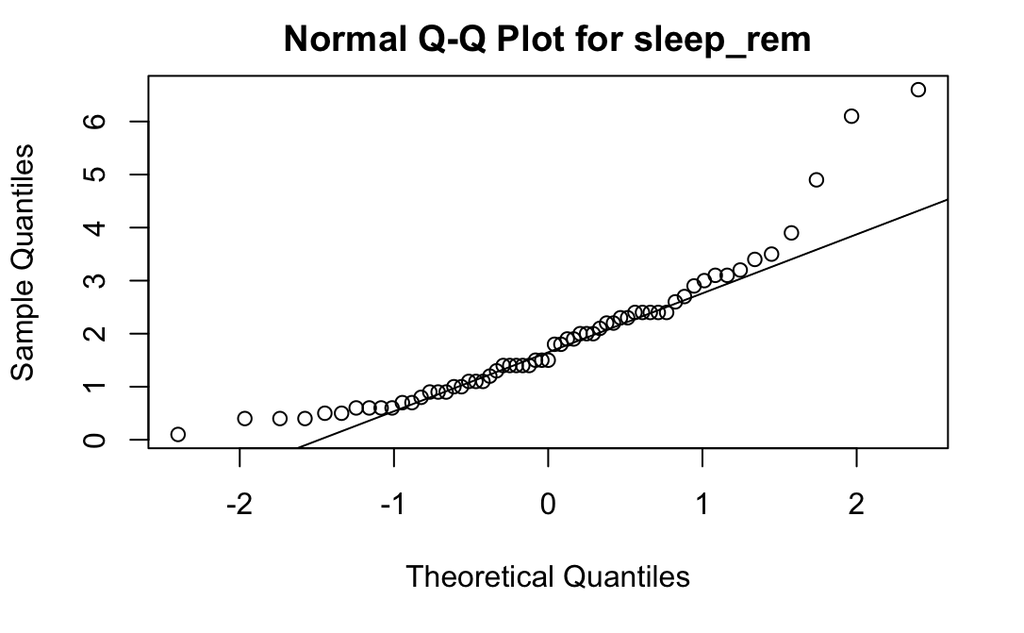

After comparing those QQ plots it should be clear that some of the data is not Normally distributed. We can test that using the Shapiro-Wilk test ‘shapiro.test()’. If the p-value is < 0.05 then we have evidence to reject the hypothesis of a normal distribution. Normally distributed data will have a p-value GREATER THAN 0.05

`r`r shapiro.test(msleep$sleep_total)

```
    Shapiro-Wilk normality test

data:  msleep$sleep_total
W = 0.97973, p-value = 0.2143
```

`r`r shapiro.test(msleep$sleep_rem)

```
    Shapiro-Wilk normality test

data:  msleep$sleep_rem
W = 0.87866, p-value = 2.078e-05
```

`r`r shapiro.test(msleep$sleep_cycle)

```
    Shapiro-Wilk normality test

data:  msleep$sleep_cycle
W = 0.80131, p-value = 4.315e-05
```

`r`r shapiro.test(msleep$awake)

```
    Shapiro-Wilk normality test

data:  msleep$awake
W = 0.97977, p-value = 0.2157
```

`r`r shapiro.test(msleep$brainwt)

```
    Shapiro-Wilk normality test

data:  msleep$brainwt
W = 0.30082, p-value = 7.277e-15
```

`r`r shapiro.test(msleep$bodywt)

```
    Shapiro-Wilk normality test

data:  msleep$bodywt
W = 0.20938, p-value < 2.2e-16
```

For most of the parameters, will either have to transform the data so that it meets the assumption of a normal distribution or we will have to use non-parametric statistical tests.

Now let’s see how the total sleep compares to REM sleep.

`r`r ggplot(msleep) + aes(x = sleep_total, y = sleep_rem) + geom_point() + theme_cowplot()

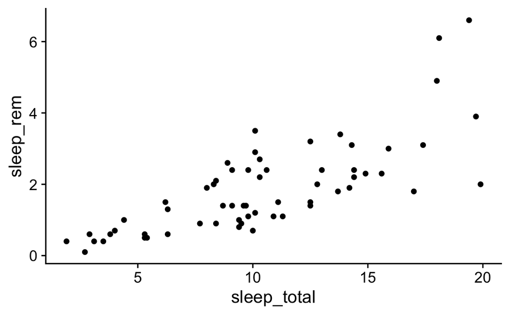

Note that some species do not have a value for sleep_rem so a warning is triggered. We can suppress that for future plots. We will also add better axis labels and legends. Now lets see how these values compare for the different feeding types.

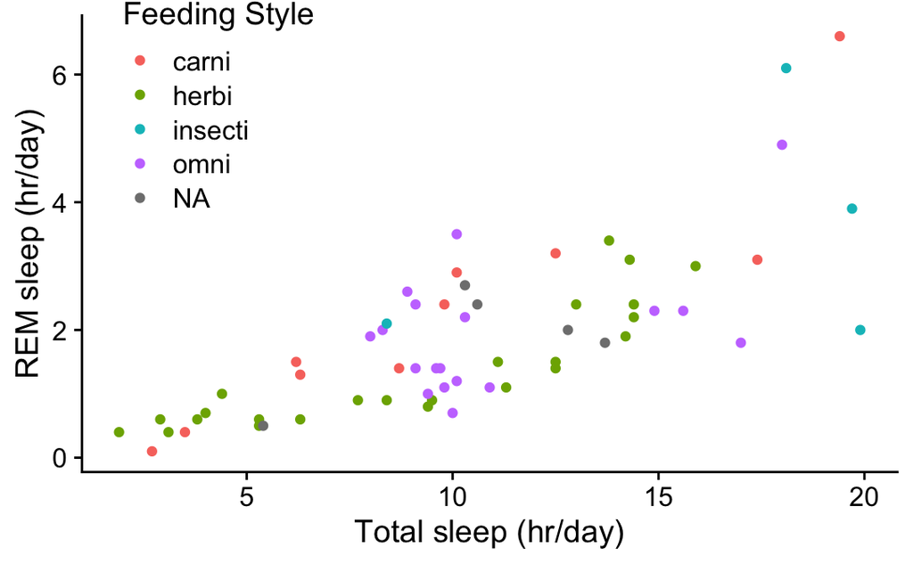

We can also bring in body weight by using a bubble plot. Because body weights cover such a broad range, we use the log10 function. We also set alpha = 0.2 for the points, so that the bubbles are somewhat transparent.

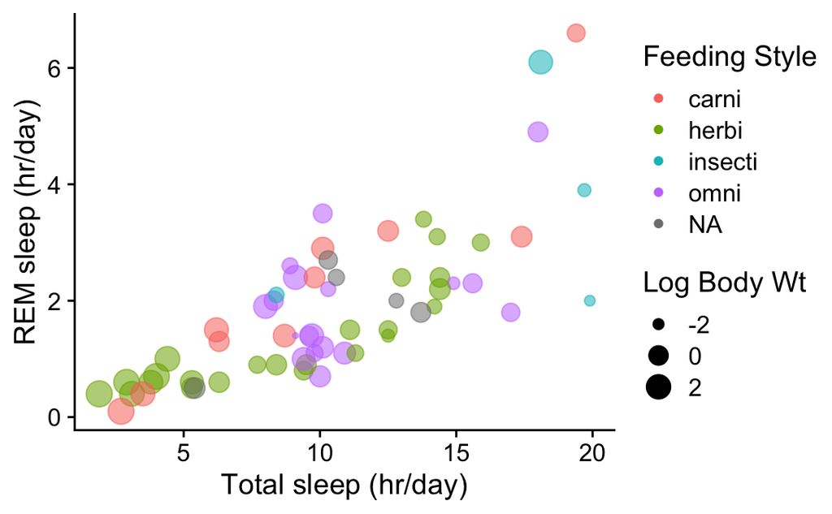

We are now approaching the maximum density of information that we can provide in one plot. The shapes of the points could also be altered, but that would interfere with the perception of the sizes. Alpha can also be set to vary based on a variable, but that would be problematic for overlapping points.

Now lets focus more on the body weight.

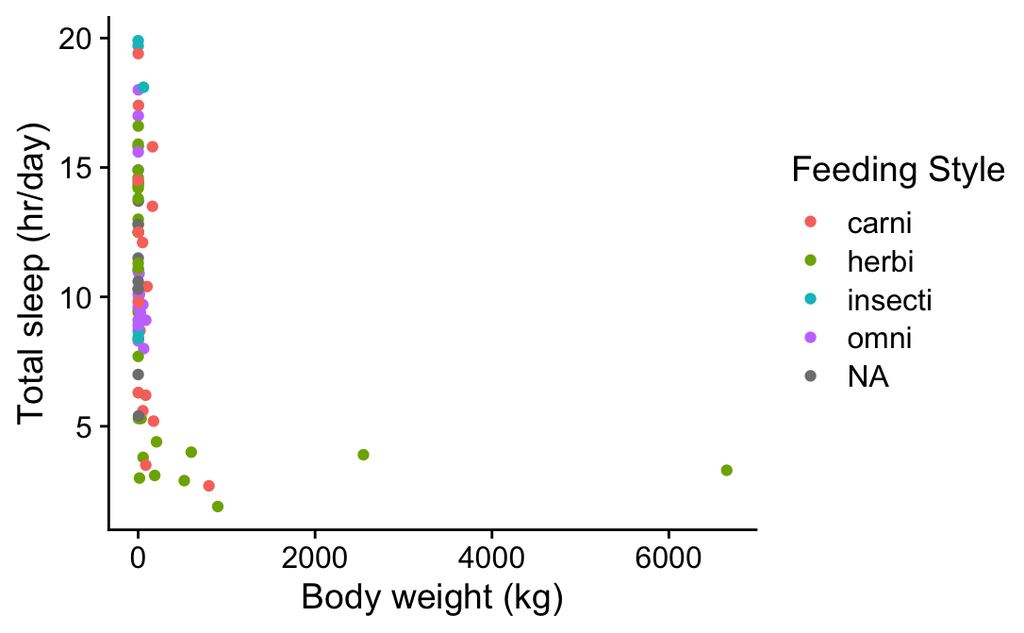

You can see why it is necessary to use a log10 scale for Body weight!

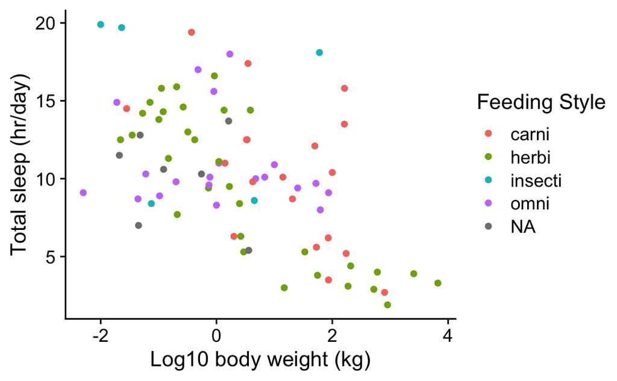

We can fit the data using a linear model - this will provide 95% confidence intervals for the fit as well.

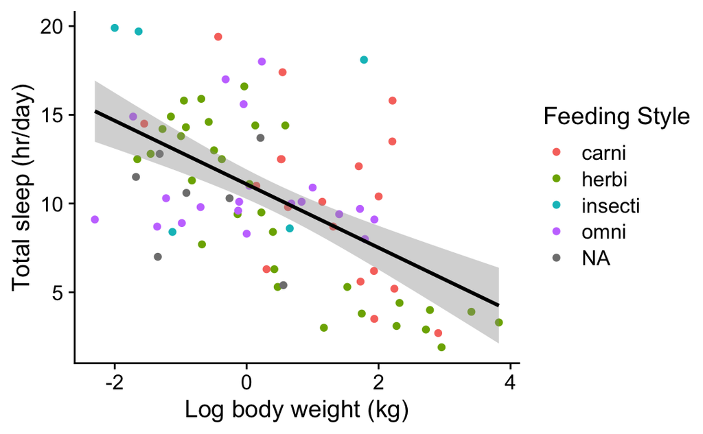

And to see the linear regression results:

`r`r sleepfit = lm(sleep_total~log10(bodywt), data=msleep) summary(sleepfit)

```
Call:
lm(formula = sleep_total ~ log10(bodywt), data = msleep)

Residuals:
    Min      1Q  Median      3Q     Max
-6.4991 -2.5671 -0.1683  2.0471 10.1928

Coefficients:
              Estimate Std. Error t value Pr(>|t|)
(Intercept)    11.0891     0.4178  26.542  < 2e-16 ***
log10(bodywt)  -1.7894     0.2876  -6.222 2.05e-08 ***
---
Signif. codes:  0 ‘***’ 0.001 ‘**’ 0.01 ‘*’ 0.05 ‘.’ 0.1 ‘ ’ 1

Residual standard error: 3.683 on 81 degrees of freedom
Multiple R-squared:  0.3233,    Adjusted R-squared:  0.315
F-statistic: 38.71 on 1 and 81 DF,  p-value: 2.046e-08
```